# Reproducible Research: Peer Assessment 1

## Loading and preprocessing the data

Create folder, download data, unzip and make data.table

```r
library(data.table)

url <- "https://d396qusza40orc.cloudfront.net/repdata%2Fdata%2Factivity.zip"
if (!file.exists("RR_proj1")) dir.create("RR_proj1")
if (!file.exists("RR_proj1/data.zip")) download.file(url, destfile = "RR_proj1/data.zip")
if (!file.exists("RR_proj1/activity.csv")) unzip("RR_proj1/data.zip", exdir="RR_proj1")
data <- read.csv("RR_proj1/activity.csv")
my_data <- data.table(data)
```

## What is mean total number of steps taken per day?

```r
total_steps <- my_data[,.(steps.sum = sum(steps, na.rm=TRUE) )]
total_steps
```

```
##    steps.sum
## 1:    570608
```

2 Histogram - total number of steps taken each day

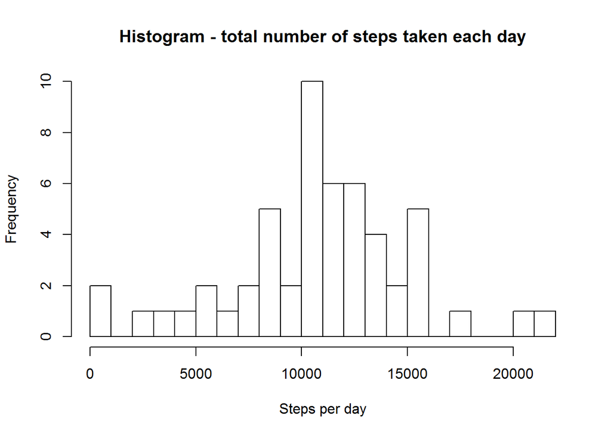

```r
steps_per_day <- my_data[,.(steps.sum = sum(steps)), by = date]
hist(steps_per_day$steps.sum,
     breaks = 20,
     main = "Histogram - total number of steps taken each day",
     xlab = "Steps per day")
```

3 Mean and median of the total number of steps taken per day.

```r
mean(steps_per_day$steps, na.rm=TRUE)
```

```
## [1] 10766.19
```

```r
median(steps_per_day$steps, na.rm=TRUE)
```

```
## [1] 10765
```

## What is the average daily activity pattern?

1 Average number of steps for each 5-minute interval

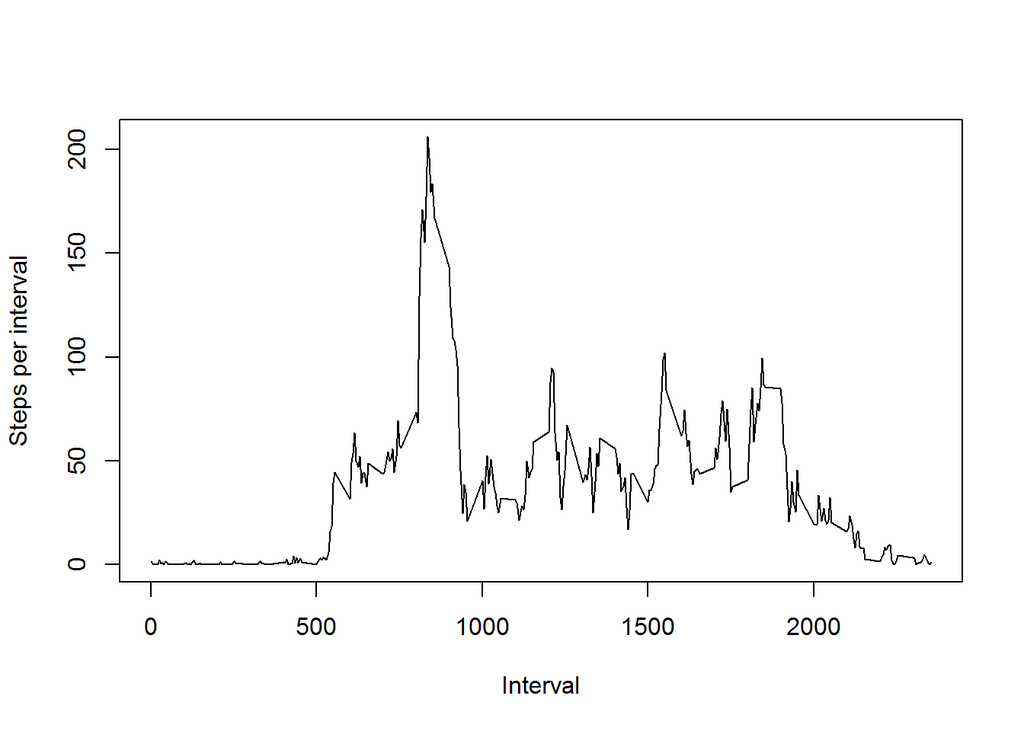

```r
intervals_mean <- with(my_data,tapply(steps,interval,mean,na.rm=TRUE))
plot(names(intervals_mean),intervals_mean,type="l",xlab="Interval",ylab ="Steps per interval")
```

2 Which 5-minute interval, on average across all the days in the dataset, contains the maximum number of steps?

```r
intervals_mean[which(intervals_mean==max(intervals_mean))]
```

```
##      835
## 206.1698
```